# 矩阵分解

## 基本概念

矩阵分解是将矩阵分解为数个矩阵的乘积，

用矩阵分解做协同过滤是广泛使用的方法

常见的有三种：

1.三角分解法

2.QR分解法

3.奇异值分解法

## 矩阵分解方法

### 奇异值分解 SVD

原始的SVD又名奇异值分解，如果是用户评分矩阵，首先需要对缺失值进行简单的不全，比如用全局平均，然后用SVD进行分解

### SVD++

SVD矩阵分解非常成功，有很多的迭代的方法，最有名的就是SVD++了。提SVD++之前，我们先看一个简单的BiasSVD：

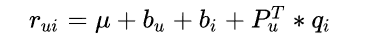

- u 为训练集中所有记录的平均全局数
- b_u 为用户的偏置项，表示用户的评分偏好
- b_i 为物品的偏置项，表示物品的本身质量

如果将用户历史行为对用户评分预测影响考虑进来就是SVD++算法：

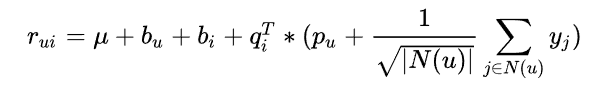

SVD++的核心思想是把基于领域的itemCF算法用矩阵分解的方法实现，转换的方法是这样的：

itemCF算法其实可以转变成

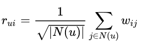

把w_{ij}不再看成是物品的相似度矩阵，而是一个和P、Q一样的参数。对w矩阵也进行分解，把参数个数降低到2nF个，

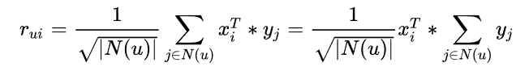

其中x_i 和 y_j是两个F维的向量

为了不增加太多参数导致过拟合，令x=q，这样就能得到上面的SVD++的模型了

### 其他

1.FM

2.隐式反馈矩阵分解

3.基于特征的矩阵分解

## 矩阵分解之 推荐系统

矩阵分解就是预测出评分矩阵中的缺失值，然后根据预测值以某种方式向用户推荐。常见的矩阵分解方法有基本矩阵分解（basic MF），正则化矩阵分解（Regularized MF）等。

对于推荐系统来说存在两大场景即评分预测（rating prediction）与Top-N推荐（item recommendation，item ranking）。评分预测场景主要用于评价网站，比如用户给自己看过的电影评多少分（MovieLens），或者用户给自己看过的书籍评价多少分（Douban）。其中矩阵分解技术主要应用于该场景。Top-N推荐场景主要用于购物网站或者一般拿不到显式评分信息的网站，即通过用户的隐式反馈信息来给用户推荐一个可能感兴趣的列表以供其参考。

有如下R（5，4）的打分矩阵：（“-”表示用户没有打分）

其中打分矩阵R（n，m）是n行和m列，n表示user个数，m表示iten个数

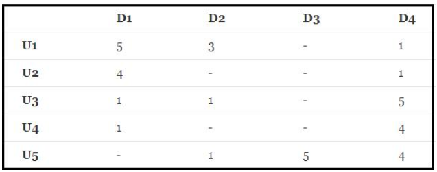

那么，如何根据目前的矩阵R（5,4）如何对未打分的商品进行评分的预测（如何得到分值为0的用户的打分值）？

——矩阵分解的思想可以解决这个问题，其实这种思想可以看作是有监督的机器学习问题（回归问题）。

矩阵R可以近似表示为P与Q的乘积：R（n,m）≈ P(n,K)*Q(K,m)

矩阵分解的过程中，将原始的评分矩阵分解成两个矩阵和的乘积：

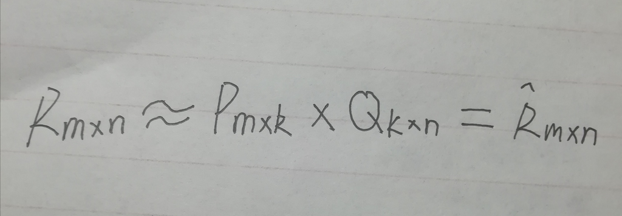

矩阵P(n,K)表示n个user和K个特征之间的关系矩阵，这K个特征是一个中间变量，矩阵Q(K,m)的转置是矩阵Q(m,K)，矩阵Q(m,K)表示m个item和K个特征之间的关系矩阵，这里的K值是自己控制的，可以使用交叉验证的方法获得最佳的K值。为了得到近似的R(n,m)，必须求出矩阵P和Q，如何求它们呢？

### 方法

#### 基本矩阵分解（basic MF）

1.首先令

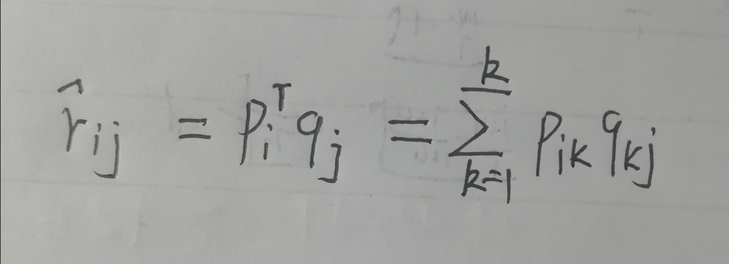

2.损失函数： 使用原始的评分矩阵与重新构建的评分矩阵之间的误差的平方作为损失函数。

如果R（i，j）已知，则R（i，j）的误差平方和为

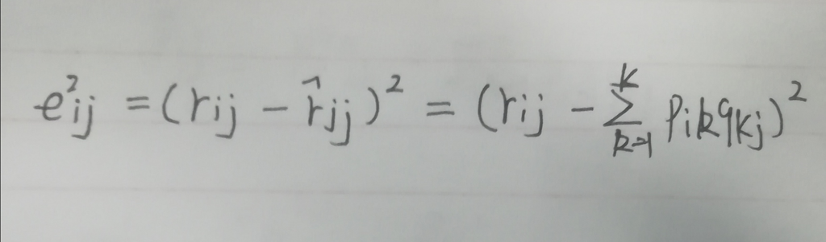

最终，需要求解所有的非“-”项的损失之和最小值：

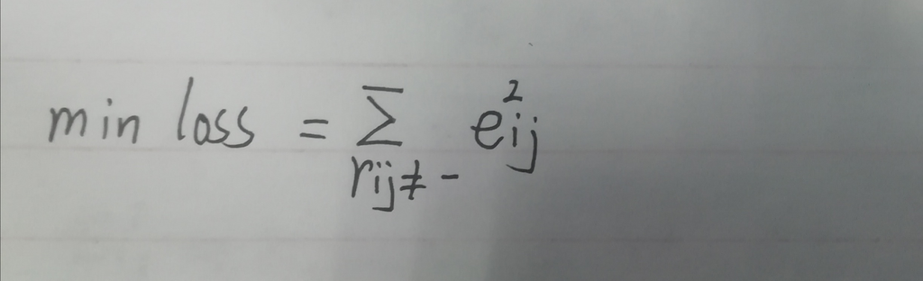

3.使用梯度下降法获得修正的p和q分量：

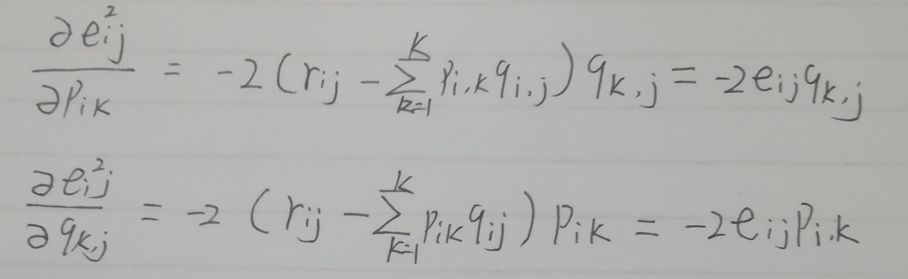

根据梯度方向更新变量

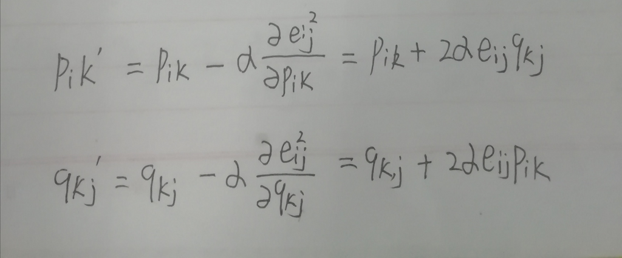

4.不停迭代直至算法最终收敛（直到sum（e^2）<=阈值